# Online Appendix D

Ambiguity attitudes and surprises

Authors

Affiliations

Aljoscha Minnich

Center for Earth System Research and Sustainability (CEN), University of Hamburg

Department of Economics, University of Hamburg

Hauke Roggenkamp

Institute of Behavioral Science and Technology, University of St. Gallen

Faculty of Economics & Social Sciences, Helmut-Schmidt-University

Andreas Lange

Center for Earth System Research and Sustainability (CEN), University of Hamburg

Department of Economics, University of Hamburg

Published

July 4, 2024

This document explains how to reproduce the analyses presented in Online Appendix D.

```r
if (!requireNamespace("groundhog", quietly = TRUE)) {
    install.packages("groundhog")
    library("groundhog")
}

pkgs <- c("magrittr", "data.table", "stringr", "lubridate", "knitr", "glue",
          "sandwich", "lmtest",
          "ggplot2", "ggpubr", "rstatix", "patchwork","sjPlot", "stargazer")

groundhog::groundhog.library(pkg = pkgs,
                             date = "2023-09-25")
```

# Read Data

```r
# data <- data.table::fread(file = "../data/processed/full.csv")
data <- readRDS(file="../data/processed/full.Rda")
```

```r
data[, communication := as.factor(communication)]
data[, communication := factor(communication, levels = c("point","both", "interval"))]
data[, stage := as.factor(stage)]
data[, stage := factor(stage, levels = c("1", "2"))]
```

# Subsets for the four different robustness checks

```r
subset1<-subset(data,data$comprehension=="rather yes"|data$comprehension=="yes")
subset2<-subset(data,data$wrong_answer_1==0&data$wrong_answer_2==0)

#calculate the 10th and 90th quantile of completion time
data$lowquantile<-quantile(data$completion_time,probs=c(0.1))
data$highquantile<-quantile(data$completion_time,probs=c(0.9))
subset3<-subset(data,data$completion_time>data$lowquantile&data$completion_time<data$highquantile)
subset4<-subset(data,data$mc>=data$ms)
subset4<-subset(subset4,duplicated(subset4$participant.label)|duplicated(subset4$participant.label,fromLast = TRUE))
```

#Table OD.1, OD.2

# Regressions

```r
demographics <- c("age_35_52","age_53_plus","female", "high_education", "high_income", "married", "parentship")

all <- c(demographics, "high_temperature","high_usage","high_general_risk","high_weather_risk","high_accuracy","high_credibility")
```

```r
event_regressions <- function(event = "b",data2=subset1){
  ols_1 <- lm(formula = reformulate(c("surprise", "treated", "surprise*treated"), response = event),
              data = data2)
  se_1  <- coeftest(x = ols_1,
                    vcov = vcovCL(ols_1,
                                  cluster = ~data2$participant.label,
                                  type = "HC1"))

  ols_2 <- lm(formula = reformulate(c("communication", "treated", "communication*treated"), response = event),
              data = data2,
              subset = (surprise == FALSE))
  se_2  <- coeftest(x = ols_2,
                    vcov = vcovCL(ols_2,
                                  cluster = data2[surprise == FALSE, participant.label],
                                  type = "HC1"))

  ols_3 <- lm(formula = reformulate(c("communication", "treated", "communication*treated"), response = event),
              data = data2,
              subset = (surprise == TRUE))
  se_3  <- coeftest(x = ols_3,
                    vcov = vcovCL(ols_3,
                                  cluster = data2[surprise == TRUE, participant.label],
                                  type = "HC1"))

  ols_4 <- lm(formula = reformulate(c("surprise", "treated", "surprise*treated"), response = event),
              data = data2,
              subset = (communication == "point"))
  se_4  <- coeftest(x = ols_4,
                    vcov = vcovCL(ols_4,
                                  cluster = data2[communication == "point", participant.label],
                                  type = "HC1"))

  ols_5 <- lm(formula = reformulate(c("surprise", "treated", "surprise*treated"), response = event),
              data = data2,
              subset = (communication == "interval"))
  se_5  <- coeftest(x = ols_5,
                    vcov = vcovCL(ols_5,
                                  cluster = data2[communication == "interval", participant.label],
                                  type = "HC1"))

  ols_6 <- lm(formula = reformulate(c("surprise", "treated", "surprise*treated"), response = event),
              data = data2,
              subset = (communication == "both"))
  se_6  <- coeftest(x = ols_6,
                    vcov = vcovCL(ols_6,
                                  cluster = data2[communication == "both", participant.label],
                                  type = "HC1"))



  se <- list(se_1[,2], se_2[,2], se_3[,2], se_4[,2], se_5[,2], se_6[,2])
  p  <- list(se_1[,4], se_2[,4], se_3[,4], se_4[,4], se_5[,4], se_6[,4])

  stargazer(ols_1, ols_2, ols_3, ols_4, ols_5, ols_6,
            align = TRUE,
            se = se,
            p = p,
            title = paste0("Linear regressions: Treatment effects on ", event),
            font.size = "scriptsize",
            type = "html",
            df = FALSE)
}
```

## b

```r
event_regressions(event = "b",data2=subset1)
```

**Linear regressions: Treatment effects on b**

|  | *Dependent variable:* |  |  |  |  |  |
| --- | --- | --- | --- | --- | --- | --- |
|  | c(“surprise”, “treated”, “surprise* treated”) | c(“communication”, “treated”, “communication* treated”) |  | c(“surprise”, “treated”, “surprise* treated”) |  |  |
|  | (1) | (2) | (3) | (4) | (5) | (6) |
| surprise | 0.005 |  |  | 0.025 | -0.021 | 0.013 |
|  | (0.017) |  |  | (0.029) | (0.029) | (0.029) |
| communicationboth |  | -0.035 | -0.048 |  |  |  |
|  |  | (0.028) | (0.030) |  |  |  |
| communicationinterval |  | -0.002 | -0.048 |  |  |  |
|  |  | (0.027) | (0.031) |  |  |  |
| treated | -0.024*** | -0.038** | -0.005 | -0.038** | -0.013 | -0.022 |
|  | (0.009) | (0.016) | (0.018) | (0.016) | (0.015) | (0.015) |
| surpriseTRUE:treated | 0.017 |  |  | 0.032 | 0.008 | 0.010 |
|  | (0.013) |  |  | (0.024) | (0.022) | (0.021) |
| communicationboth:treated |  | 0.016 | -0.006 |  |  |  |
|  |  | (0.022) | (0.023) |  |  |  |
| communicationinterval:treated |  | 0.024 | -0.0001 |  |  |  |
|  |  | (0.022) | (0.023) |  |  |  |
| Constant | -0.075*** | -0.063*** | -0.038* | -0.063*** | -0.065*** | -0.098*** |
|  | (0.012) | (0.019) | (0.022) | (0.019) | (0.020) | (0.021) |
| Observations | 2,438 | 1,210 | 1,228 | 810 | 820 | 808 |
| R<sup>2</sup> | 0.001 | 0.005 | 0.006 | 0.007 | 0.001 | 0.002 |
| Adjusted R<sup>2</sup> | 0.0001 | 0.001 | 0.001 | 0.003 | -0.003 | -0.002 |
| Residual Std. Error | 0.306 | 0.295 | 0.317 | 0.299 | 0.311 | 0.309 |
| F Statistic | 1.105 | 1.167 | 1.360 | 1.834 | 0.276 | 0.442 |
| *Note:* | *p<0.1; **p<0.05;*** p<0.01 |  |  |  |  |  |

## a

```r
event_regressions(event = "a",data2=subset1)
```

**Linear regressions: Treatment effects on a**

|  | *Dependent variable:* |  |  |  |  |  |
| --- | --- | --- | --- | --- | --- | --- |
|  | c(“surprise”, “treated”, “surprise* treated”) | c(“communication”, “treated”, “communication* treated”) |  | c(“surprise”, “treated”, “surprise* treated”) |  |  |
|  | (1) | (2) | (3) | (4) | (5) | (6) |
| surprise | -0.044 |  |  | -0.008 | -0.033 | -0.091** |
|  | (0.027) |  |  | (0.046) | (0.050) | (0.046) |
| communicationboth |  | 0.052 | -0.030 |  |  |  |
|  |  | (0.046) | (0.046) |  |  |  |
| communicationinterval |  | 0.014 | -0.011 |  |  |  |
|  |  | (0.048) | (0.049) |  |  |  |
| treated | -0.001 | 0.014 | -0.009 | 0.014 | 0.024 | -0.041 |
|  | (0.021) | (0.038) | (0.036) | (0.038) | (0.035) | (0.037) |
| surpriseTRUE:treated | 0.005 |  |  | -0.023 | -0.003 | 0.040 |
|  | (0.030) |  |  | (0.052) | (0.050) | (0.052) |
| communicationboth:treated |  | -0.055 | 0.008 |  |  |  |
|  |  | (0.053) | (0.052) |  |  |  |
| communicationinterval:treated |  | 0.011 | 0.030 |  |  |  |
|  |  | (0.052) | (0.051) |  |  |  |
| Constant | 0.739*** | 0.716*** | 0.708*** | 0.716*** | 0.731*** | 0.769*** |
|  | (0.019) | (0.032) | (0.034) | (0.032) | (0.036) | (0.034) |
| Observations | 2,438 | 1,210 | 1,228 | 810 | 820 | 808 |
| R<sup>2</sup> | 0.002 | 0.001 | 0.001 | 0.001 | 0.002 | 0.006 |
| Adjusted R<sup>2</sup> | 0.0005 | -0.003 | -0.003 | -0.003 | -0.002 | 0.002 |
| Residual Std. Error | 0.506 | 0.501 | 0.512 | 0.501 | 0.527 | 0.491 |
| F Statistic | 1.376 | 0.310 | 0.214 | 0.141 | 0.427 | 1.642 |
| *Note:* | *p<0.1; **p<0.05;*** p<0.01 |  |  |  |  |  |

# Figure OD.1

Figure 1 also presents three panels. These panels visualize confidence intervals of our estimator of interest: the interaction of `stage` and `surprise` (top panel) as well as the interaction between `stage` and `communication` in the lower two panels.

The corresponding data stems from many OLS regressions and are computed in for-loops. Even though the code differs slightly, it is very repetitive between the three panels, which is why we only explain the top panel

## Top Panel

Before calculating the data based on OLS regressions, we specify three different models: `none` represents only treatment variables, `demographics` extends the former by adding demographic variables, and `all` extends the former two by also adding all remaining covariates.

```r
none <- c("surprise", "treated", "surprise*treated")

demographics <- c(none, "age_35_52","age_53_plus","female", "high_education", "high_income", "married", "parentship")

all <- c(demographics, "high_temperature","high_usage","high_general_risk","high_weather_risk","high_accuracy","high_credibility")
```

Next, we run a nested loop that iterates through all three models and within these models through both ambiguity indices `a` and `b`. From these ols regressions, we compute clustered standard errors using the `{{sandwich}}` and `{{lmtest}}` package. The resuling data is stored in a temporary data.table that is appended to an initially empty data.table called `ci_top`.

```r
ci_top <- data.table()
for(RHS in c("none", "demographics", "all")){
  for(LHS in c("a", "b")){
    ols <- lm(formula = reformulate(termlabels = get(RHS),
                                    response = LHS),
              data = subset1)

    tmp <- coefci(x = ols,
                  parm = "surpriseTRUE:treatedTRUE",
                  vcov = vcovCL(x = ols,
                                cluster = subset1$participant.label,
                                type = "HC1"),
                  level = 0.95) %>%
      data.table(model = RHS, outcome = LHS)
    tmp[, center := (`2.5 %` + `97.5 %`)/2]

    ci_top <- rbind(ci_top, tmp)
  }
}
```

The result looks as follows. The data.table provides a column for the 2.5% and 97.5% confidence interval, the center of the two, as well as the ols specification as presented in `model` and `outcome`.

```r
ci_top %>% head(n = 7) %>% kable()
```

| 2.5 % | 97.5 % | model | outcome | center |
| --- | --- | --- | --- | --- |
| -0.0533184 | 0.0635151 | none | a | 0.0050984 |
| -0.0081381 | 0.0421343 | none | b | 0.0169981 |
| -0.0470002 | 0.0745720 | demographics | a | 0.0137859 |
| -0.0067787 | 0.0466625 | demographics | b | 0.0199419 |
| -0.0470827 | 0.0746546 | all | a | 0.0137859 |
| -0.0068150 | 0.0466988 | all | b | 0.0199419 |

Finally, we plot this data set (`ci_top`) using the `{{ggplot2}}` package. The resulting object is stored as `top` and will be assembled together with the other two panels.

```r
top <- ggplot(data = ci_top,
       mapping = aes(y = outcome)) +
  geom_pointrange(mapping = aes(x = center,
                                y = outcome,
                                xmin = `2.5 %`,
                                xmax = `97.5 %`,
                                shape = factor(model)),
                  data = ci_top,
                  position = position_dodge(width = 0.4),
                  fatten=5,
                  alpha=.8) +
  geom_vline(xintercept = 0,
             color = "red",
             alpha = 0.66,
             show.legend = FALSE) +
  theme_bw() +
  labs(#title = "(a) Effect of contradiction (relative to confirmation)",
       y = "Ambiguity Index",
       x = "Estimate",
       shape="Control variables")
```

## Left Panel

```r
none <- c("communication", "treated", "communication*treated")

demographics <- c(none, "age_35_52","age_53_plus","female", "high_education", "high_income", "married", "parentship")

all <- c(demographics, "high_temperature","high_usage","high_general_risk","high_weather_risk","high_accuracy","high_credibility")
```

```r
ci_left <- data.table()
for(RHS in c("none", "demographics", "all")){
  for(LHS in c("a", "b")){
    ols <- lm(formula = reformulate(termlabels = get(RHS),
                                    response = LHS),
              data = subset1,
              subset = (surprise == FALSE))
    for(communication in c("interval", "both")){
      tmp <- coefci(x = ols,
                    parm = paste0("communication", communication, ":treatedTRUE"),
                    vcov = vcovCL(x = ols,
                                  cluster = subset1[surprise == FALSE,
                                                 participant.label],
                                  type = "HC1"),
                    level = 0.95) %>%
        data.table(model = RHS, outcome = paste0(LHS, " (", communication, ")"))
      tmp[, center := (`2.5 %` + `97.5 %`)/2]

      ci_left <- rbind(ci_left, tmp)
    }
  }
}
```

```r
ci_left %>% head(n = 7) %>% kable()
```

| 2.5 % | 97.5 % | model | outcome | center |
| --- | --- | --- | --- | --- |
| -0.0905359 | 0.1122810 | none | a (interval) | 0.0108726 |
| -0.1576955 | 0.0484299 | none | a (both) | -0.0546328 |
| -0.0191792 | 0.0678259 | none | b (interval) | 0.0243233 |
| -0.0269219 | 0.0581065 | none | b (both) | 0.0155923 |
| -0.0858822 | 0.1246912 | demographics | a (interval) | 0.0194045 |
| -0.1729308 | 0.0385417 | demographics | a (both) | -0.0671945 |
| -0.0217223 | 0.0718577 | demographics | b (interval) | 0.0250677 |

```r
left <- ggplot(data = ci_left,
       mapping = aes(y = outcome)) +
  geom_pointrange(mapping = aes(x = center,
                                y = outcome,
                                xmin = `2.5 %`,
                                xmax = `97.5 %`,
                                shape = factor(model)),
                  data = ci_left,
                  position = position_dodge(width = 0.4),
                  fatten=5,
                  alpha=.8) +
  scale_y_discrete(limits=c("a (interval)","a (both)","b (interval)","b (both)"))+
  geom_vline(xintercept = 0,
             color = "red",
             alpha = 0.66,
             show.legend = FALSE) +
  theme_bw() +
  labs(#title = "(b) Effect of information treatments (both, interval) relative to best guess, confirmation treatments",
       y = "Ambiguity Index",
       x = "Estimate",
       shape="Control variables")
```

## Right Panel

```r
ci_right <- data.table()
for(RHS in c("none", "demographics", "all")){
  for(LHS in c("a", "b")){
    ols <- lm(formula = reformulate(termlabels = get(RHS),
                                    response = LHS),
              data = subset1,
              subset = (surprise == TRUE))
    for(communication in c("interval", "both")){
      tmp <- coefci(x = ols,
                    parm = paste0("communication", communication, ":treatedTRUE"),
                    vcov = vcovCL(x = ols,
                                  cluster = subset1[surprise == TRUE,
                                                 participant.label],
                                  type = "HC1"),
                    level = 0.95) %>%
        data.table(model = RHS, outcome = paste0(LHS, " (", communication, ")"))
      tmp[, center := (`2.5 %` + `97.5 %`)/2]

      ci_right <- rbind(ci_right, tmp)
    }
  }
}
```

```r
ci_right %>% head(n = 7) %>% kable()
```

| 2.5 % | 97.5 % | model | outcome | center |
| --- | --- | --- | --- | --- |
| -0.0692484 | 0.1296155 | none | a (interval) | 0.0301835 |
| -0.0939523 | 0.1103153 | none | a (both) | 0.0081815 |
| -0.0461422 | 0.0460028 | none | b (interval) | -0.0000697 |
| -0.0517375 | 0.0391412 | none | b (both) | -0.0062982 |
| -0.0729664 | 0.1375306 | demographics | a (interval) | 0.0322821 |
| -0.1111701 | 0.1070073 | demographics | a (both) | -0.0020814 |
| -0.0624121 | 0.0346716 | demographics | b (interval) | -0.0138702 |

```r
right <- ggplot(data = ci_right,
       mapping = aes(y = outcome)) +
  geom_pointrange(mapping = aes(x = center,
                                y = outcome,
                                xmin = `2.5 %`,
                                xmax = `97.5 %`,
                                shape = factor(model)),
                  data = ci_right,
                  position = position_dodge(width = 0.4),
                  fatten=5,
                  alpha=.8) +
  geom_vline(xintercept = 0,
             color = "red",
             alpha = 0.66,
             show.legend = FALSE) +
  theme_bw() +
  labs(#title = "(c) Effect of information treatments (both, interval) relative to best guess, contradiction treatments",
       y = "Ambiguity Index",
       x = "Estimate",
       shape="Control variables") +
  scale_y_discrete(position = "right",limits=c("a (interval)","a (both)","b (interval)","b (both)"))
```

## Assemble Top, Left and Right Panels

As before, we use the `{{patchwork}}` package to assmble the plot objects.

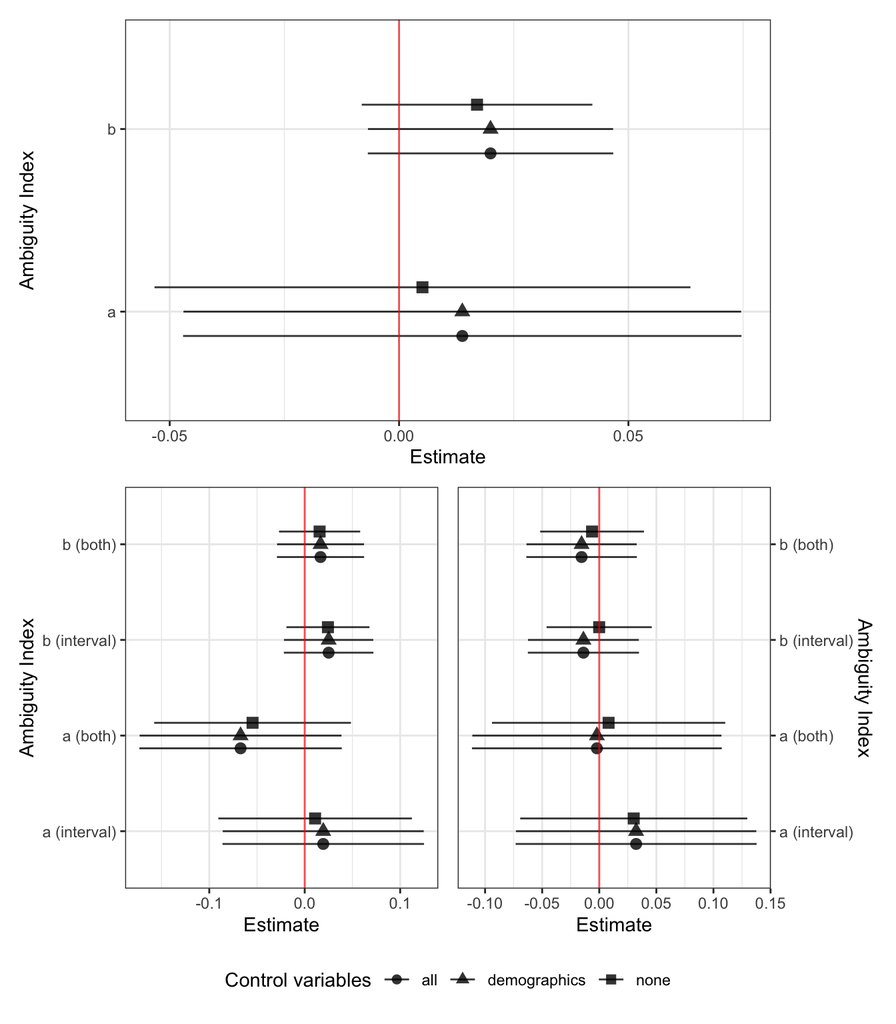

Figure 1: Treatment effects of regression equation (1) with dependent variables b and a. Estimators with 95% confidence intervals. The underlying standard errors (“HC1”) are clustered at the individual level and estimated with the R package sandwich (Zeileis, 2004; Zeileis et al., 2020).

```r
(top / (left | right) & theme(legend.position = "bottom")) + plot_layout(guides = "collect")
```

# Figure OD.2

The process of producing Figure 2 is very similar to the process of Figure 1. The only difference is that we do not loop through the outcomes `a` and `b` but the events’ matching probabilities (`E1`, `E2`, `...`, `E23`).

To loop through these variables, we use a regex (`E\\d`) to create a vector called `events`.

```r
events <- names(data) %>% str_subset(pattern = "E\\d")
```

## Top Panel

```r
none <- c("surprise", "treated", "surprise*treated")

demographics <- c(none, "age_35_52","age_53_plus","female", "high_education", "high_income", "married", "parentship")

all <- c(demographics, "high_temperature","high_usage","high_general_risk","high_weather_risk","high_accuracy","high_credibility")
```

```r
ci_top <- data.table()
for(RHS in c("none", "demographics", "all")){
  for(LHS in events){
    ols <- lm(formula = reformulate(termlabels = get(RHS),
                                    response = LHS),
              data = subset1)

    tmp <- coefci(x = ols,
                  parm = "surpriseTRUE:treatedTRUE",
                  vcov = vcovCL(x = ols,
                                cluster = subset1$participant.label,
                                type = "HC1"),
                  level = 0.95) %>% data.table(model = RHS, outcome = LHS)
    tmp[, center := (`2.5 %` + `97.5 %`)/2]

    ci_top <- rbind(ci_top, tmp)
  }
}
```

```r
ci_top %>% head(n = 7) %>% kable()
```

| 2.5 % | 97.5 % | model | outcome | center |
| --- | --- | --- | --- | --- |
| 4.469195 | 10.3148762 | none | E1 | 7.392036 |
| 1.775045 | 7.0084318 | none | E12 | 4.391738 |
| 2.469019 | 7.7152594 | none | E13 | 5.092139 |
| -8.845984 | -3.9372262 | none | E2 | -6.391605 |
| -15.197127 | -9.3798963 | none | E23 | -12.288512 |
| -5.951790 | -0.6386613 | none | E3 | -3.295226 |
| 4.054546 | 10.1983066 | demographics | E1 | 7.126427 |

```r
top <- ggplot(data = ci_top,
       mapping = aes(y = outcome)) +
  geom_pointrange(mapping = aes(x = center,
                                y = outcome,
                                xmin = `2.5 %`,
                                xmax = `97.5 %`,
                                shape = factor(model)),
                  data = ci_top,
                  position = position_dodge(width = 0.4),
                  fatten=5,
                  alpha=.8) +
  scale_y_discrete(limits=c("E13","E23","E12","E3","E2","E1"))+
  geom_vline(xintercept = 0,
             color = "red",
             alpha = 0.66,
             show.legend = FALSE) +
  theme_bw() +
  labs(y = "Ambiguity Index",
       x = "Estimate",
       shape="Control variables")
```

## Left Panel

```r
none <- c("communication", "treated", "communication*treated")

demographics <- c(none, "age_35_52","age_53_plus","female", "high_education", "high_income", "married", "parentship")

all <- c(demographics, "high_temperature","high_usage","high_general_risk","high_weather_risk","high_accuracy","high_credibility")
```

```r
ci_left <- data.table()
for(RHS in c("none", "demographics", "all")){
  for(LHS in events){
    ols <- lm(formula = reformulate(termlabels = get(RHS),
                                    response = LHS),
              data = subset1,
              subset = (surprise == FALSE))
    for(communication in c("interval", "both")){
      tmp <- coefci(x = ols,
                    parm = paste0("communication", communication, ":treatedTRUE"),
                    vcov = vcovCL(x = ols,
                                  cluster = subset1[surprise == FALSE,
                                                 participant.label],
                                  type = "HC1"),
                    level = 0.95) %>%
        data.table(model = RHS, outcome = paste0(LHS, " (", communication, ")"))
      tmp[, center := (`2.5 %` + `97.5 %`)/2]

      ci_left <- rbind(ci_left, tmp)
    }
  }
}
```

```r
ci_left %>% head(n = 7) %>% kable()
```

| 2.5 % | 97.5 % | model | outcome | center |
| --- | --- | --- | --- | --- |
| -6.379830 | 3.2600234 | none | E1 (interval) | -1.559903 |
| -7.694878 | 1.4801328 | none | E1 (both) | -3.107373 |
| -7.824397 | 0.9198828 | none | E12 (interval) | -3.452257 |
| -2.823789 | 5.6088511 | none | E12 (both) | 1.392531 |
| -2.803387 | 6.1855520 | none | E13 (interval) | 1.691082 |
| -6.434530 | 2.6590328 | none | E13 (both) | -1.887749 |
| -3.632644 | 4.1457040 | none | E2 (interval) | 0.256530 |

```r
left <- ggplot(data = ci_left,
       mapping = aes(y = outcome)) +
  geom_pointrange(mapping = aes(x = center,
                                y = outcome,
                                xmin = `2.5 %`,
                                xmax = `97.5 %`,
                                shape = factor(model)),
                  data = ci_left,
                  position = position_dodge(width = 0.4),
                  fatten=5,
                  alpha=.8) +
  scale_y_discrete(limits=c("E13 (interval)","E13 (both)","E23 (interval)","E23 (both)","E12 (interval)","E12 (both)","E3 (interval)","E3 (both)","E2 (interval)","E2 (both)","E1 (interval)","E1 (both)"))+
  geom_vline(xintercept = 0,
             color = "red",
             alpha = 0.66,
             show.legend = FALSE) +
  theme_bw() +
  labs(y = "Ambiguity Index",
       x = "Estimate",
       shape="Control variables")
```

## Right Panel

```r
ci_right <- data.table()
for(RHS in c("none", "demographics", "all")){
  for(LHS in events){
    ols <- lm(formula = reformulate(termlabels = get(RHS),
                                    response = LHS),
              data = subset1,
              subset = (surprise == TRUE))
    for(communication in c("interval", "both")){
      tmp <- coefci(x = ols,
                    parm = paste0("communication", communication, ":treatedTRUE"),
                    vcov = vcovCL(x = ols,
                                  cluster = subset1[surprise == TRUE,
                                                 participant.label],
                                  type = "HC1"),
                    level = 0.95) %>%
        data.table(model = RHS, outcome = paste0(LHS, " (", communication, ")"))
      tmp[, center := (`2.5 %` + `97.5 %`)/2]

      ci_right <- rbind(ci_right, tmp)
    }
  }
}
```

```r
ci_right %>% head(n = 7) %>% kable()
```

| 2.5 % | 97.5 % | model | outcome | center |
| --- | --- | --- | --- | --- |
| -9.076169 | 1.7284445 | none | E1 (interval) | -3.6738623 |
| -5.567350 | 5.6758383 | none | E1 (both) | 0.0542440 |
| -4.368653 | 4.9853986 | none | E12 (interval) | 0.3083729 |
| -2.112712 | 7.7407530 | none | E12 (both) | 2.8140206 |
| -8.519022 | 0.4178355 | none | E13 (interval) | -4.0505933 |
| -6.869590 | 2.8237414 | none | E13 (both) | -2.0229240 |
| -2.228124 | 6.5969401 | none | E2 (interval) | 2.1844080 |

```r
right <- ggplot(data = ci_right,
       mapping = aes(y = outcome)) +
  geom_pointrange(mapping = aes(x = center,
                                y = outcome,
                                xmin = `2.5 %`,
                                xmax = `97.5 %`,
                                shape = factor(model)),
                  data = ci_right,
                  position = position_dodge(width = 0.4),
                  fatten=5,
                  alpha=.8) +
  geom_vline(xintercept = 0,
             color = "red",
             alpha = 0.66,
             show.legend = FALSE) +
  theme_bw() +
  labs(y = "Ambiguity Index",
       x = "Estimate",
       shape="Control variables") +
  scale_y_discrete(position = "right",limits=c("E13 (interval)","E13 (both)","E23 (interval)","E23 (both)","E12 (interval)","E12 (both)","E3 (interval)","E3 (both)","E2 (interval)","E2 (both)","E1 (interval)","E1 (both)"))
```

## Assemble Top, Left and Right Panels

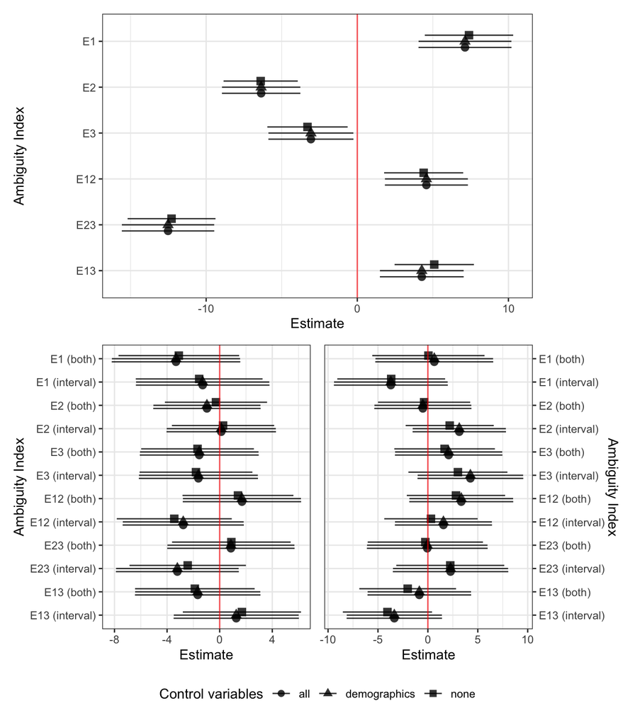

Figure 2: Treatment effects of regression equation (1) with matching probabilities for all events as depen- dent variables. Estimators with 95% confidence intervals. The underlying standard errors (“HC1”) are clustered at the individual level and estimated with the R package sandwich (Zeileis, 2004; Zeileis et al., 2020).

```r
(top / (left | right) & theme(legend.position = "bottom")) + plot_layout(guides = "collect")
```

#Table OD.3, OD.4

## b Subset 2

```r
event_regressions(event = "b",data2=subset2)
```

**Linear regressions: Treatment effects on b**

|  | *Dependent variable:* |  |  |  |  |  |
| --- | --- | --- | --- | --- | --- | --- |
|  | c(“surprise”, “treated”, “surprise* treated”) | c(“communication”, “treated”, “communication* treated”) |  | c(“surprise”, “treated”, “surprise* treated”) |  |  |
|  | (1) | (2) | (3) | (4) | (5) | (6) |
| surprise | 0.008 |  |  | 0.018 | -0.023 | 0.031 |
|  | (0.017) |  |  | (0.027) | (0.030) | (0.029) |
| communicationboth |  | -0.051* | -0.038 |  |  |  |
|  |  | (0.026) | (0.030) |  |  |  |
| communicationinterval |  | -0.019 | -0.059** |  |  |  |
|  |  | (0.027) | (0.030) |  |  |  |
| treated | -0.017* | -0.041** | -0.006 | -0.041** | -0.0002 | -0.011 |
|  | (0.010) | (0.017) | (0.016) | (0.017) | (0.016) | (0.018) |
| surpriseTRUE:treated | 0.010 |  |  | 0.034 | 0.009 | -0.012 |
|  | (0.013) |  |  | (0.023) | (0.022) | (0.025) |
| communicationboth:treated |  | 0.029 | -0.018 |  |  |  |
|  |  | (0.025) | (0.023) |  |  |  |
| communicationinterval:treated |  | 0.040* | 0.014 |  |  |  |
|  |  | (0.023) | (0.022) |  |  |  |
| Constant | -0.089*** | -0.066*** | -0.049** | -0.066*** | -0.085*** | -0.117*** |
|  | (0.011) | (0.017) | (0.021) | (0.017) | (0.021) | (0.020) |
| Observations | 2,368 | 1,172 | 1,196 | 802 | 800 | 766 |
| R<sup>2</sup> | 0.001 | 0.005 | 0.006 | 0.006 | 0.001 | 0.003 |
| Adjusted R<sup>2</sup> | -0.0003 | 0.001 | 0.002 | 0.002 | -0.003 | -0.001 |
| Residual Std. Error | 0.302 | 0.290 | 0.312 | 0.288 | 0.314 | 0.301 |
| F Statistic | 0.782 | 1.255 | 1.480 | 1.654 | 0.256 | 0.680 |
| *Note:* | *p<0.1; **p<0.05;*** p<0.01 |  |  |  |  |  |

## a SUbset2

```r
event_regressions(event = "a",data2=subset2)
```

**Linear regressions: Treatment effects on a**

|  | *Dependent variable:* |  |  |  |  |  |
| --- | --- | --- | --- | --- | --- | --- |
|  | c(“surprise”, “treated”, “surprise* treated”) | c(“communication”, “treated”, “communication* treated”) |  | c(“surprise”, “treated”, “surprise* treated”) |  |  |
|  | (1) | (2) | (3) | (4) | (5) | (6) |
| surprise | -0.024 |  |  | 0.013 | -0.022 | -0.065 |
|  | (0.027) |  |  | (0.049) | (0.048) | (0.045) |
| communicationboth |  | 0.062 | -0.016 |  |  |  |
|  |  | (0.047) | (0.046) |  |  |  |
| communicationinterval |  | 0.039 | 0.004 |  |  |  |
|  |  | (0.048) | (0.049) |  |  |  |
| treated | -0.005 | 0.031 | -0.002 | 0.031 | -0.010 | -0.038 |
|  | (0.021) | (0.039) | (0.037) | (0.039) | (0.033) | (0.039) |
| surpriseTRUE:treated | 0.013 |  |  | -0.033 | 0.011 | 0.064 |
|  | (0.030) |  |  | (0.054) | (0.049) | (0.055) |
| communicationboth:treated |  | -0.070 | 0.028 |  |  |  |
|  |  | (0.055) | (0.054) |  |  |  |
| communicationinterval:treated |  | -0.041 | 0.003 |  |  |  |
|  |  | (0.051) | (0.052) |  |  |  |
| Constant | 0.734*** | 0.701*** | 0.714*** | 0.701*** | 0.740*** | 0.763*** |
|  | (0.019) | (0.034) | (0.035) | (0.034) | (0.034) | (0.032) |
| Observations | 2,368 | 1,172 | 1,196 | 802 | 800 | 766 |
| R<sup>2</sup> | 0.0004 | 0.001 | 0.0003 | 0.0005 | 0.0003 | 0.002 |
| Adjusted R<sup>2</sup> | -0.001 | -0.003 | -0.004 | -0.003 | -0.003 | -0.002 |
| Residual Std. Error | 0.495 | 0.486 | 0.505 | 0.511 | 0.498 | 0.477 |
| F Statistic | 0.281 | 0.339 | 0.063 | 0.128 | 0.084 | 0.605 |
| *Note:* | *p<0.1; **p<0.05;*** p<0.01 |  |  |  |  |  |

# Figure OD.3

Figure 3 also presents three panels. These panels visualize confidence intervals of our estimator of interest: the interaction of `stage` and `surprise` (top panel) as well as the interaction between `stage` and `communication` in the lower two panels.

The corresponding data stems from many OLS regressions and are computed in for-loops. Even though the code differs slightly, it is very repetitive between the three panels, which is why we only explain the top panel

## Top Panel 2

Before calculating the data based on OLS regressions, we specify three different models: `none` represents only treatment variables, `demographics` extends the former by adding demographic variables, and `all` extends the former two by also adding all remaining covariates.

```r
none <- c("surprise", "treated", "surprise*treated")

demographics <- c(none, "age_35_52","age_53_plus","female", "high_education", "high_income", "married", "parentship")

all <- c(demographics, "high_temperature","high_usage","high_general_risk","high_weather_risk","high_accuracy","high_credibility")
```

Next, we run a nested loop that iterates through all three models and within these models through both ambiguity indices `a` and `b`. From these ols regressions, we compute clustered standard errors using the `{{sandwich}}` and `{{lmtest}}` package. The resuling data is stored in a temporary data.table that is appended to an initially empty data.table called `ci_top`.

```r
ci_top <- data.table()
for(RHS in c("none", "demographics", "all")){
  for(LHS in c("a", "b")){
    ols <- lm(formula = reformulate(termlabels = get(RHS),
                                    response = LHS),
              data = subset2)

    tmp <- coefci(x = ols,
                  parm = "surpriseTRUE:treatedTRUE",
                  vcov = vcovCL(x = ols,
                                cluster = subset2$participant.label,
                                type = "HC1"),
                  level = 0.95) %>%
      data.table(model = RHS, outcome = LHS)
    tmp[, center := (`2.5 %` + `97.5 %`)/2]

    ci_top <- rbind(ci_top, tmp)
  }
}
```

```
ci_top %>% head(n = 7) %>% kable()
```

Finally, we plot this data set (`ci_top`) using the `{{ggplot2}}` package. The resulting object is stored as `top` and will be assembled together with the other two panels.

```r
top <- ggplot(data = ci_top,
              mapping = aes(y = outcome)) +
  geom_pointrange(mapping = aes(x = center,
                                y = outcome,
                                xmin = `2.5 %`,
                                xmax = `97.5 %`,
                                shape = factor(model)),
                  data = ci_top,
                  position = position_dodge(width = 0.4),
                  fatten=5,
                  alpha=.8) +
  geom_vline(xintercept = 0,
             color = "red",
             alpha = 0.66,
             show.legend = FALSE) +
  theme_bw() +
  labs(#title = "(a) Effect of contradiction (relative to confirmation)",
    y = "Ambiguity Index",
    x = "Estimate",
    shape="Control variables")
```

## Left Panel 2

```r
none <- c("communication", "treated", "communication*treated")

demographics <- c(none, "age_35_52","age_53_plus","female", "high_education", "high_income", "married", "parentship")

all <- c(demographics, "high_temperature","high_usage","high_general_risk","high_weather_risk","high_accuracy","high_credibility")
```

```r
ci_left <- data.table()
for(RHS in c("none", "demographics", "all")){
  for(LHS in c("a", "b")){
    ols <- lm(formula = reformulate(termlabels = get(RHS),
                                    response = LHS),
              data = subset2,
              subset = (surprise == FALSE))
    for(communication in c("interval", "both")){
      tmp <- coefci(x = ols,
                    parm = paste0("communication", communication, ":treatedTRUE"),
                    vcov = vcovCL(x = ols,
                                  cluster = subset2[surprise == FALSE,
                                                    participant.label],
                                  type = "HC1"),
                    level = 0.95) %>%
        data.table(model = RHS, outcome = paste0(LHS, " (", communication, ")"))
      tmp[, center := (`2.5 %` + `97.5 %`)/2]

      ci_left <- rbind(ci_left, tmp)
    }
  }
}
```

```
ci_left %>% head(n = 7) %>% kable()
```

```r
left <- ggplot(data = ci_left,
               mapping = aes(y = outcome)) +
  geom_pointrange(mapping = aes(x = center,
                                y = outcome,
                                xmin = `2.5 %`,
                                xmax = `97.5 %`,
                                shape = factor(model)),
                  data = ci_left,
                  position = position_dodge(width = 0.4),
                  fatten=5,
                  alpha=.8) +
  scale_y_discrete(limits=c("a (interval)","a (both)","b (interval)","b (both)"))+
  geom_vline(xintercept = 0,
             color = "red",
             alpha = 0.66,
             show.legend = FALSE) +
  theme_bw() +
  labs(#title = "(b) Effect of information treatments (both, interval) relative to best guess, confirmation treatments",
    y = "Ambiguity Index",
    x = "Estimate",
    shape="Control variables")
```

## Right Panel 2

```r
ci_right <- data.table()
for(RHS in c("none", "demographics", "all")){
  for(LHS in c("a", "b")){
    ols <- lm(formula = reformulate(termlabels = get(RHS),
                                    response = LHS),
              data = subset2,
              subset = (surprise == TRUE))
    for(communication in c("interval", "both")){
      tmp <- coefci(x = ols,
                    parm = paste0("communication", communication, ":treatedTRUE"),
                    vcov = vcovCL(x = ols,
                                  cluster = subset2[surprise == TRUE,
                                                    participant.label],
                                  type = "HC1"),
                    level = 0.95) %>%
        data.table(model = RHS, outcome = paste0(LHS, " (", communication, ")"))
      tmp[, center := (`2.5 %` + `97.5 %`)/2]

      ci_right <- rbind(ci_right, tmp)
    }
  }
}
```

```
ci_right %>% head(n = 7) %>% kable()
```

```r
right <- ggplot(data = ci_right,
                mapping = aes(y = outcome)) +
  geom_pointrange(mapping = aes(x = center,
                                y = outcome,
                                xmin = `2.5 %`,
                                xmax = `97.5 %`,
                                shape = factor(model)),
                  data = ci_right,
                  position = position_dodge(width = 0.4),
                  fatten=5,
                  alpha=.8) +
  geom_vline(xintercept = 0,
             color = "red",
             alpha = 0.66,
             show.legend = FALSE) +
  theme_bw() +
  labs(#title = "(c) Effect of information treatments (both, interval) relative to best guess, contradiction treatments",
    y = "Ambiguity Index",
    x = "Estimate",
    shape="Control variables") +
  scale_y_discrete(position = "right",limits=c("a (interval)","a (both)","b (interval)","b (both)"))
```

## Assemble Top, Left and Right Panels 2

As before, we use the `{{patchwork}}` package to assmble the plot objects.

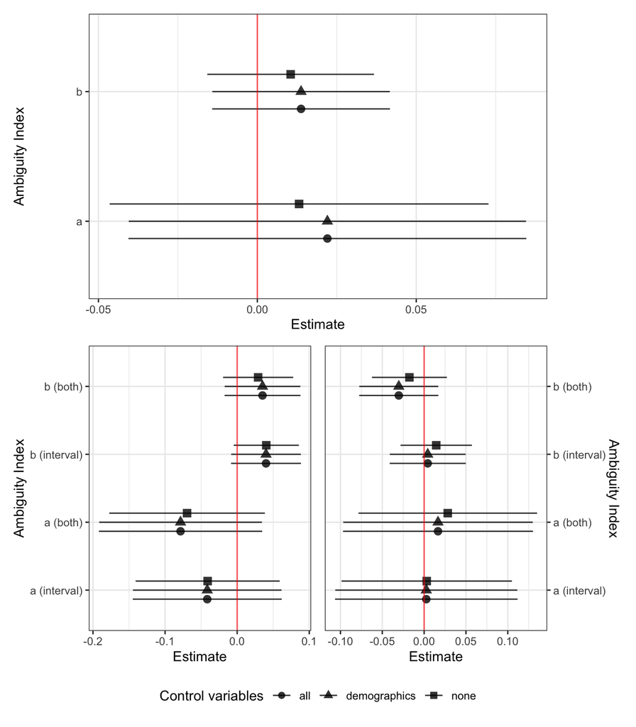

Figure 3: Treatment effects of regression equation (1) with dependent variables b and a. Estimators with 95% confidence intervals. The underlying standard errors (“HC1”) are clustered at the individual level and estimated with the R package sandwich (Zeileis, 2004; Zeileis et al., 2020).

```r
(top / (left | right) & theme(legend.position = "bottom")) + plot_layout(guides = "collect")
```

# Figure OD.4

The process of producing Figure 4 is very similar to the process of Figure 3. The only difference is that we do not loop through the outcomes `a` and `b` but the events’ matching probabilities (`E1`, `E2`, `...`, `E23`).

To loop through these variables, we use a regex (`E\\d`) to create a vector called `events`.

```r
events <- names(data) %>% str_subset(pattern = "E\\d")
```

## Top Panel 2

```r
none <- c("surprise", "treated", "surprise*treated")

demographics <- c(none, "age_35_52","age_53_plus","female", "high_education", "high_income", "married", "parentship")

all <- c(demographics, "high_temperature","high_usage","high_general_risk","high_weather_risk","high_accuracy","high_credibility")
```

```r
ci_top <- data.table()
for(RHS in c("none", "demographics", "all")){
  for(LHS in events){
    ols <- lm(formula = reformulate(termlabels = get(RHS),
                                    response = LHS),
              data = subset2)

    tmp <- coefci(x = ols,
                  parm = "surpriseTRUE:treatedTRUE",
                  vcov = vcovCL(x = ols,
                                cluster = subset2$participant.label,
                                type = "HC1"),
                  level = 0.95) %>% data.table(model = RHS, outcome = LHS)
    tmp[, center := (`2.5 %` + `97.5 %`)/2]

    ci_top <- rbind(ci_top, tmp)
  }
}
```

```
ci_top %>% head(n = 7) %>% kable()
```

```r
top <- ggplot(data = ci_top,
       mapping = aes(y = outcome)) +
  geom_pointrange(mapping = aes(x = center,
                                y = outcome,
                                xmin = `2.5 %`,
                                xmax = `97.5 %`,
                                shape = factor(model)),
                  data = ci_top,
                  position = position_dodge(width = 0.4),
                  fatten=5,
                  alpha=.8) +
  scale_y_discrete(limits=c("E13","E23","E12","E3","E2","E1"))+
  geom_vline(xintercept = 0,
             color = "red",
             alpha = 0.66,
             show.legend = FALSE) +
  theme_bw() +
  labs(y = "Ambiguity Index",
       x = "Estimate",
       shape="Control variables")
```

## Left Panel 2

```r
none <- c("communication", "treated", "communication*treated")

demographics <- c(none, "age_35_52","age_53_plus","female", "high_education", "high_income", "married", "parentship")

all <- c(demographics, "high_temperature","high_usage","high_general_risk","high_weather_risk","high_accuracy","high_credibility")
```

```r
ci_left <- data.table()
for(RHS in c("none", "demographics", "all")){
  for(LHS in events){
    ols <- lm(formula = reformulate(termlabels = get(RHS),
                                    response = LHS),
              data = subset2,
              subset = (surprise == FALSE))
    for(communication in c("interval", "both")){
      tmp <- coefci(x = ols,
                    parm = paste0("communication", communication, ":treatedTRUE"),
                    vcov = vcovCL(x = ols,
                                  cluster = subset2[surprise == FALSE,
                                                 participant.label],
                                  type = "HC1"),
                    level = 0.95) %>%
        data.table(model = RHS, outcome = paste0(LHS, " (", communication, ")"))
      tmp[, center := (`2.5 %` + `97.5 %`)/2]

      ci_left <- rbind(ci_left, tmp)
    }
  }
}
```

```
ci_left %>% head(n = 7) %>% kable()
```

```r
left <- ggplot(data = ci_left,
       mapping = aes(y = outcome)) +
  geom_pointrange(mapping = aes(x = center,
                                y = outcome,
                                xmin = `2.5 %`,
                                xmax = `97.5 %`,
                                shape = factor(model)),
                  data = ci_left,
                  position = position_dodge(width = 0.4),
                  fatten=5,
                  alpha=.8) +
  scale_y_discrete(limits=c("E13 (interval)","E13 (both)","E23 (interval)","E23 (both)","E12 (interval)","E12 (both)","E3 (interval)","E3 (both)","E2 (interval)","E2 (both)","E1 (interval)","E1 (both)"))+
  geom_vline(xintercept = 0,
             color = "red",
             alpha = 0.66,
             show.legend = FALSE) +
  theme_bw() +
  labs(y = "Ambiguity Index",
       x = "Estimate",
       shape="Control variables")
```

## Right Panel 2

```r
ci_right <- data.table()
for(RHS in c("none", "demographics", "all")){
  for(LHS in events){
    ols <- lm(formula = reformulate(termlabels = get(RHS),
                                    response = LHS),
              data = subset2,
              subset = (surprise == TRUE))
    for(communication in c("interval", "both")){
      tmp <- coefci(x = ols,
                    parm = paste0("communication", communication, ":treatedTRUE"),
                    vcov = vcovCL(x = ols,
                                  cluster = subset2[surprise == TRUE,
                                                 participant.label],
                                  type = "HC1"),
                    level = 0.95) %>%
        data.table(model = RHS, outcome = paste0(LHS, " (", communication, ")"))
      tmp[, center := (`2.5 %` + `97.5 %`)/2]

      ci_right <- rbind(ci_right, tmp)
    }
  }
}
```

```
ci_right %>% head(n = 7) %>% kable()
```

```r
right <- ggplot(data = ci_right,
       mapping = aes(y = outcome)) +
  geom_pointrange(mapping = aes(x = center,
                                y = outcome,
                                xmin = `2.5 %`,
                                xmax = `97.5 %`,
                                shape = factor(model)),
                  data = ci_right,
                  position = position_dodge(width = 0.4),
                  fatten=5,
                  alpha=.8) +
  geom_vline(xintercept = 0,
             color = "red",
             alpha = 0.66,
             show.legend = FALSE) +
  theme_bw() +
  labs(y = "Ambiguity Index",
       x = "Estimate",
       shape="Control variables") +
  scale_y_discrete(position = "right",limits=c("E13 (interval)","E13 (both)","E23 (interval)","E23 (both)","E12 (interval)","E12 (both)","E3 (interval)","E3 (both)","E2 (interval)","E2 (both)","E1 (interval)","E1 (both)"))
```

## Assemble Top, Left and Right Panels 2

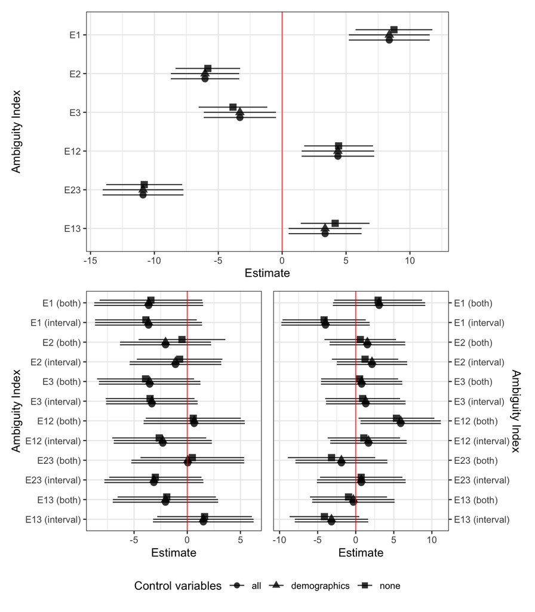

Figure 4: Treatment effects of regression equation (1) with matching probabilities for all events as depen- dent variables. Estimators with 95% confidence intervals. The underlying standard errors (“HC1”) are clustered at the individual level and estimated with the R package sandwich (Zeileis, 2004; Zeileis et al., 2020).

```r
(top / (left | right) & theme(legend.position = "bottom")) + plot_layout(guides = "collect")
```

#Table OD.5, OD.6

## b 3

```r
event_regressions(event = "b",data2=subset3)
```

**Linear regressions: Treatment effects on b**

|  | *Dependent variable:* |  |  |  |  |  |
| --- | --- | --- | --- | --- | --- | --- |
|  | c(“surprise”, “treated”, “surprise* treated”) | c(“communication”, “treated”, “communication* treated”) |  | c(“surprise”, “treated”, “surprise* treated”) |  |  |
|  | (1) | (2) | (3) | (4) | (5) | (6) |
| surprise | 0.011 |  |  | 0.028 | -0.020 | 0.027 |
|  | (0.016) |  |  | (0.027) | (0.029) | (0.030) |
| communicationboth |  | -0.020 | -0.020 |  |  |  |
|  |  | (0.027) | (0.030) |  |  |  |
| communicationinterval |  | 0.011 | -0.037 |  |  |  |
|  |  | (0.026) | (0.029) |  |  |  |
| treated | -0.022** | -0.039** | -0.003 | -0.039** | -0.016 | -0.008 |
|  | (0.010) | (0.016) | (0.016) | (0.016) | (0.017) | (0.017) |
| surpriseTRUE:treated | 0.008 |  |  | 0.037 | 0.006 | -0.020 |
|  | (0.013) |  |  | (0.023) | (0.023) | (0.023) |
| communicationboth:treated |  | 0.031 | -0.026 |  |  |  |
|  |  | (0.024) | (0.022) |  |  |  |
| communicationinterval:treated |  | 0.023 | -0.008 |  |  |  |
|  |  | (0.024) | (0.023) |  |  |  |
| Constant | -0.079*** | -0.076*** | -0.048** | -0.076*** | -0.065*** | -0.095*** |
|  | (0.011) | (0.016) | (0.021) | (0.016) | (0.021) | (0.021) |
| Observations | 2,404 | 1,198 | 1,206 | 808 | 800 | 796 |
| R<sup>2</sup> | 0.002 | 0.004 | 0.004 | 0.010 | 0.001 | 0.002 |
| Adjusted R<sup>2</sup> | 0.0003 | -0.001 | 0.00002 | 0.006 | -0.002 | -0.002 |
| Residual Std. Error | 0.297 | 0.286 | 0.307 | 0.277 | 0.303 | 0.311 |
| F Statistic | 1.277 | 0.852 | 1.005 | 2.589* | 0.353 | 0.497 |
| *Note:* | *p<0.1; **p<0.05;*** p<0.01 |  |  |  |  |  |

## a 3

```r
event_regressions(event = "a",data2=subset3)
```

**Linear regressions: Treatment effects on a**

|  | *Dependent variable:* |  |  |  |  |  |
| --- | --- | --- | --- | --- | --- | --- |
|  | c(“surprise”, “treated”, “surprise* treated”) | c(“communication”, “treated”, “communication* treated”) |  | c(“surprise”, “treated”, “surprise* treated”) |  |  |
|  | (1) | (2) | (3) | (4) | (5) | (6) |
| surprise | -0.015 |  |  | 0.039 | -0.011 | -0.074* |
|  | (0.028) |  |  | (0.048) | (0.051) | (0.045) |
| communicationboth |  | 0.065 | -0.048 |  |  |  |
|  |  | (0.047) | (0.046) |  |  |  |
| communicationinterval |  | 0.043 | -0.007 |  |  |  |
|  |  | (0.051) | (0.049) |  |  |  |
| treated | -0.004 | 0.026 | -0.026 | 0.026 | -0.003 | -0.035 |
|  | (0.023) | (0.040) | (0.037) | (0.040) | (0.038) | (0.038) |
| surpriseTRUE:treated | -0.016 |  |  | -0.053 | -0.040 | 0.046 |
|  | (0.031) |  |  | (0.055) | (0.052) | (0.052) |
| communicationboth:treated |  | -0.062 | 0.037 |  |  |  |
|  |  | (0.056) | (0.051) |  |  |  |
| communicationinterval:treated |  | -0.030 | -0.017 |  |  |  |
|  |  | (0.056) | (0.051) |  |  |  |
| Constant | 0.733*** | 0.698*** | 0.736*** | 0.698*** | 0.740*** | 0.763*** |
|  | (0.020) | (0.034) | (0.034) | (0.034) | (0.038) | (0.032) |
| Observations | 2,404 | 1,198 | 1,206 | 808 | 800 | 796 |
| R<sup>2</sup> | 0.001 | 0.001 | 0.001 | 0.001 | 0.002 | 0.004 |
| Adjusted R<sup>2</sup> | -0.001 | -0.003 | -0.003 | -0.003 | -0.002 | -0.0002 |
| Residual Std. Error | 0.513 | 0.520 | 0.506 | 0.517 | 0.541 | 0.480 |
| F Statistic | 0.560 | 0.348 | 0.348 | 0.213 | 0.443 | 0.956 |
| *Note:* | *p<0.1; **p<0.05;*** p<0.01 |  |  |  |  |  |

# Figure OD.5

Figure 1 also presents three panels. These panels visualize confidence intervals of our estimator of interest: the interaction of `stage` and `surprise` (top panel) as well as the interaction between `stage` and `communication` in the lower two panels.

The corresponding data stems from many OLS regressions and are computed in for-loops. Even though the code differs slightly, it is very repetitive between the three panels, which is why we only explain the top panel

## Top Panel 3

Before calculating the data based on OLS regressions, we specify three different models: `none` represents only treatment variables, `demographics` extends the former by adding demographic variables, and `all` extends the former two by also adding all remaining covariates.

```r
none <- c("surprise", "treated", "surprise*treated")

demographics <- c(none, "age_35_52","age_53_plus","female", "high_education", "high_income", "married", "parentship")

all <- c(demographics, "high_temperature","high_usage","high_general_risk","high_weather_risk","high_accuracy","high_credibility")
```

Next, we run a nested loop that iterates through all three models and within these models through both ambiguity indices `a` and `b`. From these ols regressions, we compute clustered standard errors using the `{{sandwich}}` and `{{lmtest}}` package. The resuling data is stored in a temporary data.table that is appended to an initially empty data.table called `ci_top`.

```r
ci_top <- data.table()
for(RHS in c("none", "demographics", "all")){
  for(LHS in c("a", "b")){
    ols <- lm(formula = reformulate(termlabels = get(RHS),
                                    response = LHS),
              data = subset3)

    tmp <- coefci(x = ols,
                  parm = "surpriseTRUE:treatedTRUE",
                  vcov = vcovCL(x = ols,
                                cluster = subset3$participant.label,
                                type = "HC1"),
                  level = 0.95) %>%
      data.table(model = RHS, outcome = LHS)
    tmp[, center := (`2.5 %` + `97.5 %`)/2]

    ci_top <- rbind(ci_top, tmp)
  }
}
```

```
ci_top %>% head(n = 7) %>% kable()
```

Finally, we plot this data set (`ci_top`) using the `{{ggplot2}}` package. The resulting object is stored as `top` and will be assembled together with the other two panels.

```r
top <- ggplot(data = ci_top,
              mapping = aes(y = outcome)) +
  geom_pointrange(mapping = aes(x = center,
                                y = outcome,
                                xmin = `2.5 %`,
                                xmax = `97.5 %`,
                                shape = factor(model)),
                  data = ci_top,
                  position = position_dodge(width = 0.4),
                  fatten=5,
                  alpha=.8) +
  geom_vline(xintercept = 0,
             color = "red",
             alpha = 0.66,
             show.legend = FALSE) +
  theme_bw() +
  labs(#title = "(a) Effect of contradiction (relative to confirmation)",
    y = "Ambiguity Index",
    x = "Estimate",
    shape="Control variables")
```

## Left Panel 3

```r
none <- c("communication", "treated", "communication*treated")

demographics <- c(none, "age_35_52","age_53_plus","female", "high_education", "high_income", "married", "parentship")

all <- c(demographics, "high_temperature","high_usage","high_general_risk","high_weather_risk","high_accuracy","high_credibility")
```

```r
ci_left <- data.table()
for(RHS in c("none", "demographics", "all")){
  for(LHS in c("a", "b")){
    ols <- lm(formula = reformulate(termlabels = get(RHS),
                                    response = LHS),
              data = subset3,
              subset = (surprise == FALSE))
    for(communication in c("interval", "both")){
      tmp <- coefci(x = ols,
                    parm = paste0("communication", communication, ":treatedTRUE"),
                    vcov = vcovCL(x = ols,
                                  cluster = subset3[surprise == FALSE,
                                                    participant.label],
                                  type = "HC1"),
                    level = 0.95) %>%
        data.table(model = RHS, outcome = paste0(LHS, " (", communication, ")"))
      tmp[, center := (`2.5 %` + `97.5 %`)/2]

      ci_left <- rbind(ci_left, tmp)
    }
  }
}
```

```
ci_left %>% head(n = 7) %>% kable()
```

```r
left <- ggplot(data = ci_left,
               mapping = aes(y = outcome)) +
  geom_pointrange(mapping = aes(x = center,
                                y = outcome,
                                xmin = `2.5 %`,
                                xmax = `97.5 %`,
                                shape = factor(model)),
                  data = ci_left,
                  position = position_dodge(width = 0.4),
                  fatten=5,
                  alpha=.8) +
  scale_y_discrete(limits=c("a (interval)","a (both)","b (interval)","b (both)"))+
  geom_vline(xintercept = 0,
             color = "red",
             alpha = 0.66,
             show.legend = FALSE) +
  theme_bw() +
  labs(#title = "(b) Effect of information treatments (both, interval) relative to best guess, confirmation treatments",
    y = "Ambiguity Index",
    x = "Estimate",
    shape="Control variables")
```

## Right Panel 3

```r
ci_right <- data.table()
for(RHS in c("none", "demographics", "all")){
  for(LHS in c("a", "b")){
    ols <- lm(formula = reformulate(termlabels = get(RHS),
                                    response = LHS),
              data = subset3,
              subset = (surprise == TRUE))
    for(communication in c("interval", "both")){
      tmp <- coefci(x = ols,
                    parm = paste0("communication", communication, ":treatedTRUE"),
                    vcov = vcovCL(x = ols,
                                  cluster = subset3[surprise == TRUE,
                                                    participant.label],
                                  type = "HC1"),
                    level = 0.95) %>%
        data.table(model = RHS, outcome = paste0(LHS, " (", communication, ")"))
      tmp[, center := (`2.5 %` + `97.5 %`)/2]

      ci_right <- rbind(ci_right, tmp)
    }
  }
}
```

```
ci_right %>% head(n = 7) %>% kable()
```

```r
right <- ggplot(data = ci_right,
                mapping = aes(y = outcome)) +
  geom_pointrange(mapping = aes(x = center,
                                y = outcome,
                                xmin = `2.5 %`,
                                xmax = `97.5 %`,
                                shape = factor(model)),
                  data = ci_right,
                  position = position_dodge(width = 0.4),
                  fatten=5,
                  alpha=.8) +
  geom_vline(xintercept = 0,
             color = "red",
             alpha = 0.66,
             show.legend = FALSE) +
  theme_bw() +
  labs(#title = "(c) Effect of information treatments (both, interval) relative to best guess, contradiction treatments",
    y = "Ambiguity Index",
    x = "Estimate",
    shape="Control variables") +
  scale_y_discrete(position = "right",limits=c("a (interval)","a (both)","b (interval)","b (both)"))
```

## Assemble Top, Left and Right Panels 3

As before, we use the `{{patchwork}}` package to assmble the plot objects.

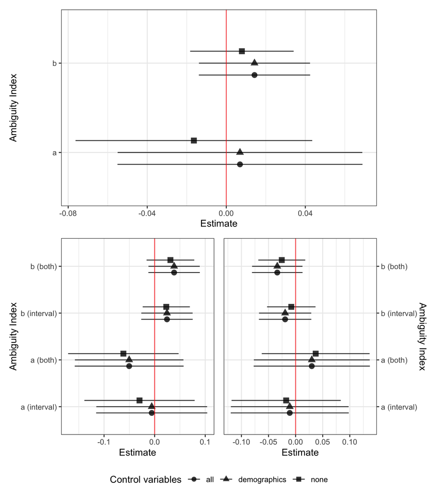

Figure 5: Treatment effects of regression equation (1) with dependent variables b and a. Estimators with 95% confidence intervals. The underlying standard errors (“HC1”) are clustered at the individual level and estimated with the R package sandwich (Zeileis, 2004; Zeileis et al., 2020).

```r
(top / (left | right) & theme(legend.position = "bottom")) + plot_layout(guides = "collect")
```

# Figure OD.6

The process of producing Figure 2 is very similar to the process of Figure 1. The only difference is that we do not loop through the outcomes `a` and `b` but the events’ matching probabilities (`E1`, `E2`, `...`, `E23`).

To loop through these variables, we use a regex (`E\\d`) to create a vector called `events`.

```r
events <- names(data) %>% str_subset(pattern = "E\\d")
```

## Top Panel 3

```r
none <- c("surprise", "treated", "surprise*treated")

demographics <- c(none, "age_35_52","age_53_plus","female", "high_education", "high_income", "married", "parentship")

all <- c(demographics, "high_temperature","high_usage","high_general_risk","high_weather_risk","high_accuracy","high_credibility")
```

```r
ci_top <- data.table()
for(RHS in c("none", "demographics", "all")){
  for(LHS in events){
    ols <- lm(formula = reformulate(termlabels = get(RHS),
                                    response = LHS),
              data = subset3)

    tmp <- coefci(x = ols,
                  parm = "surpriseTRUE:treatedTRUE",
                  vcov = vcovCL(x = ols,
                                cluster = subset3$participant.label,
                                type = "HC1"),
                  level = 0.95) %>% data.table(model = RHS, outcome = LHS)
    tmp[, center := (`2.5 %` + `97.5 %`)/2]

    ci_top <- rbind(ci_top, tmp)
  }
}
```

```
ci_top %>% head(n = 7) %>% kable()
```

```r
top <- ggplot(data = ci_top,
       mapping = aes(y = outcome)) +
  geom_pointrange(mapping = aes(x = center,
                                y = outcome,
                                xmin = `2.5 %`,
                                xmax = `97.5 %`,
                                shape = factor(model)),
                  data = ci_top,
                  position = position_dodge(width = 0.4),
                  fatten=5,
                  alpha=.8) +
  scale_y_discrete(limits=c("E13","E23","E12","E3","E2","E1"))+
  geom_vline(xintercept = 0,
             color = "red",
             alpha = 0.66,
             show.legend = FALSE) +
  theme_bw() +
  labs(y = "Ambiguity Index",
       x = "Estimate",
       shape="Control variables")
```

## Left Panel 3

```r
none <- c("communication", "treated", "communication*treated")

demographics <- c(none, "age_35_52","age_53_plus","female", "high_education", "high_income", "married", "parentship")

all <- c(demographics, "high_temperature","high_usage","high_general_risk","high_weather_risk","high_accuracy","high_credibility")
```

```r
ci_left <- data.table()
for(RHS in c("none", "demographics", "all")){
  for(LHS in events){
    ols <- lm(formula = reformulate(termlabels = get(RHS),
                                    response = LHS),
              data = subset3,
              subset = (surprise == FALSE))
    for(communication in c("interval", "both")){
      tmp <- coefci(x = ols,
                    parm = paste0("communication", communication, ":treatedTRUE"),
                    vcov = vcovCL(x = ols,
                                  cluster = subset3[surprise == FALSE,
                                                 participant.label],
                                  type = "HC1"),
                    level = 0.95) %>%
        data.table(model = RHS, outcome = paste0(LHS, " (", communication, ")"))
      tmp[, center := (`2.5 %` + `97.5 %`)/2]

      ci_left <- rbind(ci_left, tmp)
    }
  }
}
```

```
ci_left %>% head(n = 7) %>% kable()
```

```r
left <- ggplot(data = ci_left,
       mapping = aes(y = outcome)) +
  geom_pointrange(mapping = aes(x = center,
                                y = outcome,
                                xmin = `2.5 %`,
                                xmax = `97.5 %`,
                                shape = factor(model)),
                  data = ci_left,
                  position = position_dodge(width = 0.4),
                  fatten=5,
                  alpha=.8) +
  scale_y_discrete(limits=c("E13 (interval)","E13 (both)","E23 (interval)","E23 (both)","E12 (interval)","E12 (both)","E3 (interval)","E3 (both)","E2 (interval)","E2 (both)","E1 (interval)","E1 (both)"))+
  geom_vline(xintercept = 0,
             color = "red",
             alpha = 0.66,
             show.legend = FALSE) +
  theme_bw() +
  labs(y = "Ambiguity Index",
       x = "Estimate",
       shape="Control variables")
```

## Right Panel 3

```r
ci_right <- data.table()
for(RHS in c("none", "demographics", "all")){
  for(LHS in events){
    ols <- lm(formula = reformulate(termlabels = get(RHS),
                                    response = LHS),
              data = subset3,
              subset = (surprise == TRUE))
    for(communication in c("interval", "both")){
      tmp <- coefci(x = ols,
                    parm = paste0("communication", communication, ":treatedTRUE"),
                    vcov = vcovCL(x = ols,
                                  cluster = subset3[surprise == TRUE,
                                                 participant.label],
                                  type = "HC1"),
                    level = 0.95) %>%
        data.table(model = RHS, outcome = paste0(LHS, " (", communication, ")"))
      tmp[, center := (`2.5 %` + `97.5 %`)/2]

      ci_right <- rbind(ci_right, tmp)
    }
  }
}
```

```
ci_right %>% head(n = 7) %>% kable()
```

```r
right <- ggplot(data = ci_right,
       mapping = aes(y = outcome)) +
  geom_pointrange(mapping = aes(x = center,
                                y = outcome,
                                xmin = `2.5 %`,
                                xmax = `97.5 %`,
                                shape = factor(model)),
                  data = ci_right,
                  position = position_dodge(width = 0.4),
                  fatten=5,
                  alpha=.8) +
  geom_vline(xintercept = 0,
             color = "red",
             alpha = 0.66,
             show.legend = FALSE) +
  theme_bw() +
  labs(y = "Ambiguity Index",
       x = "Estimate",
       shape="Control variables") +
  scale_y_discrete(position = "right",limits=c("E13 (interval)","E13 (both)","E23 (interval)","E23 (both)","E12 (interval)","E12 (both)","E3 (interval)","E3 (both)","E2 (interval)","E2 (both)","E1 (interval)","E1 (both)"))
```

## Assemble Top, Left and Right Panels 3

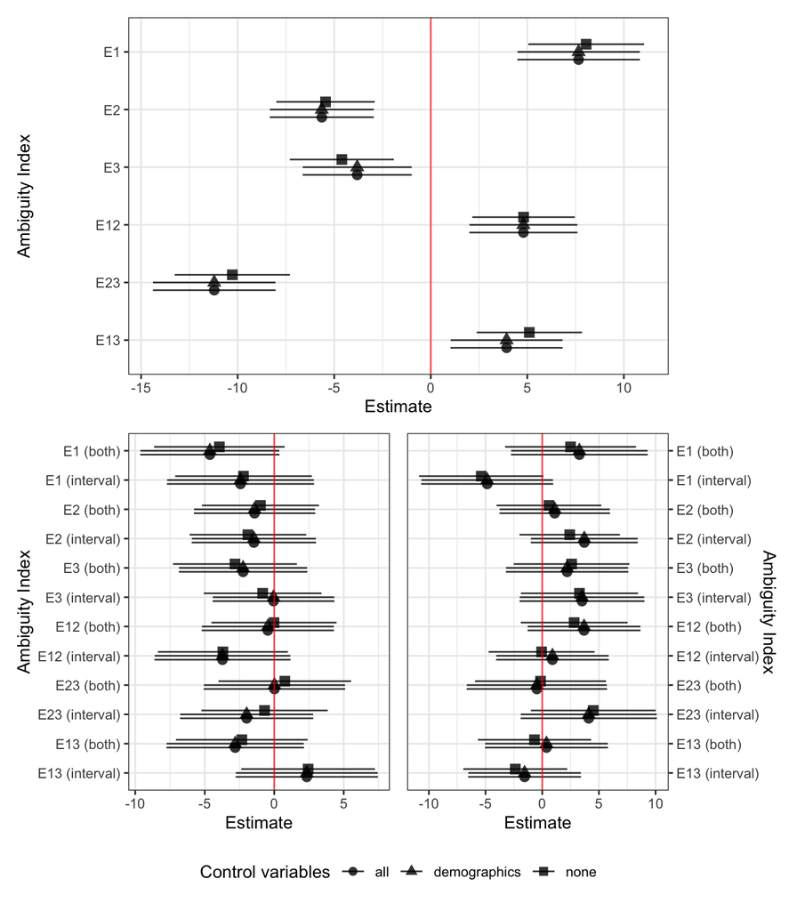

Figure 6: Treatment effects of regression equation (1) with matching probabilities for all events as depen- dent variables. Estimators with 95% confidence intervals. The underlying standard errors (“HC1”) are clustered at the individual level and estimated with the R package sandwich (Zeileis, 2004; Zeileis et al., 2020).

```r
(top / (left | right) & theme(legend.position = "bottom")) + plot_layout(guides = "collect")
```

#Table OD.7, OD.8

## b 4

```r
event_regressions(event = "b",data2=subset4)
```

**Linear regressions: Treatment effects on b**

|  | *Dependent variable:* |  |  |  |  |  |
| --- | --- | --- | --- | --- | --- | --- |
|  | c(“surprise”, “treated”, “surprise* treated”) | c(“communication”, “treated”, “communication* treated”) |  | c(“surprise”, “treated”, “surprise* treated”) |  |  |
|  | (1) | (2) | (3) | (4) | (5) | (6) |
| surprise | 0.011 |  |  | 0.025 | -0.002 | 0.012 |
|  | (0.018) |  |  | (0.030) | (0.031) | (0.032) |
| communicationboth |  | -0.050 | -0.063** |  |  |  |
|  |  | (0.031) | (0.031) |  |  |  |
| communicationinterval |  | 0.004 | -0.023 |  |  |  |
|  |  | (0.029) | (0.032) |  |  |  |
| treated | -0.017** | -0.027* | -0.013 | -0.027* | -0.023 | 0.0005 |
|  | (0.008) | (0.014) | (0.016) | (0.014) | (0.015) | (0.013) |
| surpriseTRUE:treated | 0.002 |  |  | 0.014 | 0.004 | -0.013 |
|  | (0.012) |  |  | (0.022) | (0.021) | (0.020) |
| communicationboth:treated |  | 0.027 | -0.00004 |  |  |  |
|  |  | (0.020) | (0.022) |  |  |  |
| communicationinterval:treated |  | 0.004 | -0.006 |  |  |  |
|  |  | (0.021) | (0.022) |  |  |  |
| Constant | -0.071*** | -0.057*** | -0.032 | -0.057*** | -0.053** | -0.106*** |
|  | (0.012) | (0.020) | (0.023) | (0.020) | (0.021) | (0.024) |
| Observations | 1,936 | 926 | 1,010 | 650 | 654 | 632 |
| R<sup>2</sup> | 0.001 | 0.006 | 0.008 | 0.005 | 0.001 | 0.0003 |
| Adjusted R<sup>2</sup> | -0.0004 | 0.0003 | 0.003 | 0.0004 | -0.003 | -0.004 |
| Residual Std. Error | 0.290 | 0.280 | 0.298 | 0.273 | 0.300 | 0.296 |
| F Statistic | 0.744 | 1.052 | 1.614 | 1.079 | 0.265 | 0.069 |
| *Note:* | *p<0.1; **p<0.05;*** p<0.01 |  |  |  |  |  |

## a 4

```r
event_regressions(event = "a",data2=subset4)
```

**Linear regressions: Treatment effects on a**

|  | *Dependent variable:* |  |  |  |  |  |
| --- | --- | --- | --- | --- | --- | --- |
|  | c(“surprise”, “treated”, “surprise* treated”) | c(“communication”, “treated”, “communication* treated”) |  | c(“surprise”, “treated”, “surprise* treated”) |  |  |
|  | (1) | (2) | (3) | (4) | (5) | (6) |
| surprise | -0.033 |  |  | -0.043 | -0.012 | -0.046 |
|  | (0.024) |  |  | (0.040) | (0.042) | (0.041) |
| communicationboth |  | 0.019 | 0.017 |  |  |  |
|  |  | (0.043) | (0.038) |  |  |  |
| communicationinterval |  | -0.017 | 0.014 |  |  |  |
|  |  | (0.043) | (0.039) |  |  |  |
| treated | -0.043*** | -0.018 | -0.050* | -0.018 | -0.061** | -0.053* |
|  | (0.016) | (0.025) | (0.028) | (0.025) | (0.030) | (0.028) |
| surpriseTRUE:treated | 0.001 |  |  | -0.032 | 0.021 | 0.016 |
|  | (0.023) |  |  | (0.038) | (0.041) | (0.039) |
| communicationboth:treated |  | -0.035 | 0.013 |  |  |  |
|  |  | (0.038) | (0.039) |  |  |  |
| communicationinterval:treated |  | -0.043 | 0.010 |  |  |  |
|  |  | (0.039) | (0.040) |  |  |  |
| Constant | 0.538*** | 0.537*** | 0.494*** | 0.537*** | 0.520*** | 0.557*** |
|  | (0.018) | (0.029) | (0.027) | (0.029) | (0.031) | (0.031) |
| Observations | 1,936 | 926 | 1,010 | 650 | 654 | 632 |
| R<sup>2</sup> | 0.005 | 0.006 | 0.004 | 0.009 | 0.004 | 0.006 |
| Adjusted R<sup>2</sup> | 0.003 | 0.001 | -0.001 | 0.004 | -0.001 | 0.001 |
| Residual Std. Error | 0.383 | 0.386 | 0.380 | 0.374 | 0.402 | 0.372 |
| F Statistic | 3.169** | 1.126 | 0.772 | 1.900 | 0.880 | 1.298 |
| *Note:* | *p<0.1; **p<0.05;*** p<0.01 |  |  |  |  |  |

# Figure OD.7

Figure 1 also presents three panels. These panels visualize confidence intervals of our estimator of interest: the interaction of `stage` and `surprise` (top panel) as well as the interaction between `stage` and `communication` in the lower two panels.

The corresponding data stems from many OLS regressions and are computed in for-loops. Even though the code differs slightly, it is very repetitive between the three panels, which is why we only explain the top panel

## Top Panel9

Before calculating the data based on OLS regressions, we specify three different models: `none` represents only treatment variables, `demographics` extends the former by adding demographic variables, and `all` extends the former two by also adding all remaining covariates.

```r
none <- c("surprise", "treated", "surprise*treated")

demographics <- c(none, "age_35_52","age_53_plus","female", "high_education", "high_income", "married", "parentship")

all <- c(demographics, "high_temperature","high_usage","high_general_risk","high_weather_risk","high_accuracy","high_credibility")
```

Next, we run a nested loop that iterates through all three models and within these models through both ambiguity indices `a` and `b`. From these ols regressions, we compute clustered standard errors using the `{{sandwich}}` and `{{lmtest}}` package. The resuling data is stored in a temporary data.table that is appended to an initially empty data.table called `ci_top`.

```r
ci_top <- data.table()
for(RHS in c("none", "demographics", "all")){
  for(LHS in c("a", "b")){
    ols <- lm(formula = reformulate(termlabels = get(RHS),
                                    response = LHS),
              data = subset4)

    tmp <- coefci(x = ols,
                  parm = "surpriseTRUE:treatedTRUE",
                  vcov = vcovCL(x = ols,
                                cluster = subset4$participant.label,
                                type = "HC1"),
                  level = 0.95) %>%
      data.table(model = RHS, outcome = LHS)
    tmp[, center := (`2.5 %` + `97.5 %`)/2]

    ci_top <- rbind(ci_top, tmp)
  }
}
```

```
ci_top %>% head(n = 7) %>% kable()
```

Finally, we plot this data set (`ci_top`) using the `{{ggplot2}}` package. The resulting object is stored as `top` and will be assembled together with the other two panels.

```r
top <- ggplot(data = ci_top,
              mapping = aes(y = outcome)) +
  geom_pointrange(mapping = aes(x = center,
                                y = outcome,
                                xmin = `2.5 %`,
                                xmax = `97.5 %`,
                                shape = factor(model)),
                  data = ci_top,
                  position = position_dodge(width = 0.4),
                  fatten=5,
                  alpha=.8) +
  geom_vline(xintercept = 0,
             color = "red",
             alpha = 0.66,
             show.legend = FALSE) +
  theme_bw() +
  labs(#title = "(a) Effect of contradiction (relative to confirmation)",
    y = "Ambiguity Index",
    x = "Estimate",
    shape="Control variables")
```

## Left Panel

```r
none <- c("communication", "treated", "communication*treated")

demographics <- c(none, "age_35_52","age_53_plus","female", "high_education", "high_income", "married", "parentship")

all <- c(demographics, "high_temperature","high_usage","high_general_risk","high_weather_risk","high_accuracy","high_credibility")
```

```r
ci_left <- data.table()
for(RHS in c("none", "demographics", "all")){
  for(LHS in c("a", "b")){
    ols <- lm(formula = reformulate(termlabels = get(RHS),
                                    response = LHS),
              data = subset4,
              subset = (surprise == FALSE))
    for(communication in c("interval", "both")){
      tmp <- coefci(x = ols,
                    parm = paste0("communication", communication, ":treatedTRUE"),
                    vcov = vcovCL(x = ols,
                                  cluster = subset4[surprise == FALSE,
                                                    participant.label],
                                  type = "HC1"),
                    level = 0.95) %>%
        data.table(model = RHS, outcome = paste0(LHS, " (", communication, ")"))
      tmp[, center := (`2.5 %` + `97.5 %`)/2]

      ci_left <- rbind(ci_left, tmp)
    }
  }
}
```

```
ci_left %>% head(n = 7) %>% kable()
```

```r
left <- ggplot(data = ci_left,
               mapping = aes(y = outcome)) +
  geom_pointrange(mapping = aes(x = center,
                                y = outcome,
                                xmin = `2.5 %`,
                                xmax = `97.5 %`,
                                shape = factor(model)),
                  data = ci_left,
                  position = position_dodge(width = 0.4),
                  fatten=5,
                  alpha=.8) +
  scale_y_discrete(limits=c("a (interval)","a (both)","b (interval)","b (both)"))+
  geom_vline(xintercept = 0,
             color = "red",
             alpha = 0.66,
             show.legend = FALSE) +
  theme_bw() +
  labs(#title = "(b) Effect of information treatments (both, interval) relative to best guess, confirmation treatments",
    y = "Ambiguity Index",
    x = "Estimate",
    shape="Control variables")
```

## Right Panel

```r
ci_right <- data.table()
for(RHS in c("none", "demographics", "all")){
  for(LHS in c("a", "b")){
    ols <- lm(formula = reformulate(termlabels = get(RHS),
                                    response = LHS),
              data = subset4,
              subset = (surprise == TRUE))
    for(communication in c("interval", "both")){
      tmp <- coefci(x = ols,
                    parm = paste0("communication", communication, ":treatedTRUE"),
                    vcov = vcovCL(x = ols,
                                  cluster = subset4[surprise == TRUE,
                                                    participant.label],
                                  type = "HC1"),
                    level = 0.95) %>%
        data.table(model = RHS, outcome = paste0(LHS, " (", communication, ")"))
      tmp[, center := (`2.5 %` + `97.5 %`)/2]

      ci_right <- rbind(ci_right, tmp)
    }
  }
}
```

```
ci_right %>% head(n = 7) %>% kable()
```

```r
right <- ggplot(data = ci_right,
                mapping = aes(y = outcome)) +
  geom_pointrange(mapping = aes(x = center,
                                y = outcome,
                                xmin = `2.5 %`,
                                xmax = `97.5 %`,
                                shape = factor(model)),
                  data = ci_right,
                  position = position_dodge(width = 0.4),
                  fatten=5,
                  alpha=.8) +
  geom_vline(xintercept = 0,
             color = "red",
             alpha = 0.66,
             show.legend = FALSE) +
  theme_bw() +
  labs(#title = "(c) Effect of information treatments (both, interval) relative to best guess, contradiction treatments",
    y = "Ambiguity Index",
    x = "Estimate",
    shape="Control variables") +
  scale_y_discrete(position = "right",limits=c("a (interval)","a (both)","b (interval)","b (both)"))
```

## Assemble Top, Left and Right Panels

As before, we use the `{{patchwork}}` package to assmble the plot objects.

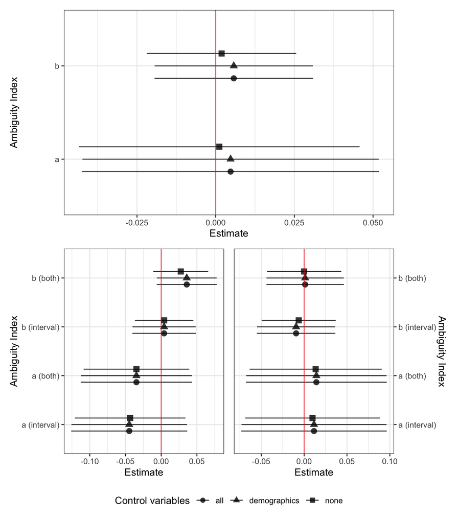

Figure 7: Treatment effects of regression equation (1) with dependent variables b and a. Estimators with 95% confidence intervals. The underlying standard errors (“HC1”) are clustered at the individual level and estimated with the R package sandwich (Zeileis, 2004; Zeileis et al., 2020).

```r
(top / (left | right) & theme(legend.position = "bottom")) + plot_layout(guides = "collect")
```

# Figure OD.8

The process of producing Figure 2 is very similar to the process of Figure 1. The only difference is that we do not loop through the outcomes `a` and `b` but the events’ matching probabilities (`E1`, `E2`, `...`, `E23`).

To loop through these variables, we use a regex (`E\\d`) to create a vector called `events`.

```r
events <- names(data) %>% str_subset(pattern = "E\\d")
```

## Top Panel

```r
none <- c("surprise", "treated", "surprise*treated")

demographics <- c(none, "age_35_52","age_53_plus","female", "high_education", "high_income", "married", "parentship")

all <- c(demographics, "high_temperature","high_usage","high_general_risk","high_weather_risk","high_accuracy","high_credibility")
```

```r
ci_top <- data.table()
for(RHS in c("none", "demographics", "all")){
  for(LHS in events){
    ols <- lm(formula = reformulate(termlabels = get(RHS),
                                    response = LHS),
              data = subset4)

    tmp <- coefci(x = ols,
                  parm = "surpriseTRUE:treatedTRUE",
                  vcov = vcovCL(x = ols,
                                cluster = subset4$participant.label,
                                type = "HC1"),
                  level = 0.95) %>% data.table(model = RHS, outcome = LHS)
    tmp[, center := (`2.5 %` + `97.5 %`)/2]

    ci_top <- rbind(ci_top, tmp)
  }
}
```

```
ci_top %>% head(n = 7) %>% kable()
```

```r
top <- ggplot(data = ci_top,
       mapping = aes(y = outcome)) +
  geom_pointrange(mapping = aes(x = center,
                                y = outcome,
                                xmin = `2.5 %`,
                                xmax = `97.5 %`,
                                shape = factor(model)),
                  data = ci_top,
                  position = position_dodge(width = 0.4),
                  fatten=5,
                  alpha=.8) +
  scale_y_discrete(limits=c("E13","E23","E12","E3","E2","E1"))+
  geom_vline(xintercept = 0,
             color = "red",
             alpha = 0.66,
             show.legend = FALSE) +
  theme_bw() +
  labs(y = "Ambiguity Index",
       x = "Estimate",
       shape="Control variables")
```

## Left Panel

```r
none <- c("communication", "treated", "communication*treated")

demographics <- c(none, "age_35_52","age_53_plus","female", "high_education", "high_income", "married", "parentship")

all <- c(demographics, "high_temperature","high_usage","high_general_risk","high_weather_risk","high_accuracy","high_credibility")
```

```r
ci_left <- data.table()
for(RHS in c("none", "demographics", "all")){
  for(LHS in events){
    ols <- lm(formula = reformulate(termlabels = get(RHS),
                                    response = LHS),
              data = subset4,
              subset = (surprise == FALSE))
    for(communication in c("interval", "both")){
      tmp <- coefci(x = ols,
                    parm = paste0("communication", communication, ":treatedTRUE"),
                    vcov = vcovCL(x = ols,
                                  cluster = subset4[surprise == FALSE,
                                                 participant.label],
                                  type = "HC1"),
                    level = 0.95) %>%
        data.table(model = RHS, outcome = paste0(LHS, " (", communication, ")"))
      tmp[, center := (`2.5 %` + `97.5 %`)/2]

      ci_left <- rbind(ci_left, tmp)
    }
  }
}
```

```r
ci_left %>% head(n = 7) %>% kable()
```

| 2.5 % | 97.5 % | model | outcome | center |
| --- | --- | --- | --- | --- |
| -6.3331379 | 2.198992 | none | E1 (interval) | -2.067073 |
| -5.8121761 | 1.630732 | none | E1 (both) | -2.090722 |
| -5.4174458 | 2.902424 | none | E12 (interval) | -1.257511 |
| -5.3933945 | 1.923388 | none | E12 (both) | -1.735003 |
| -3.1229478 | 6.190425 | none | E13 (interval) | 1.533738 |
| -6.1708645 | 2.592915 | none | E13 (both) | -1.788975 |
| -0.8001162 | 7.196821 | none | E2 (interval) | 3.198352 |

```r
left <- ggplot(data = ci_left,
       mapping = aes(y = outcome)) +
  geom_pointrange(mapping = aes(x = center,
                                y = outcome,
                                xmin = `2.5 %`,
                                xmax = `97.5 %`,
                                shape = factor(model)),
                  data = ci_left,
                  position = position_dodge(width = 0.4),
                  fatten=5,
                  alpha=.8) +
  scale_y_discrete(limits=c("E13 (interval)","E13 (both)","E23 (interval)","E23 (both)","E12 (interval)","E12 (both)","E3 (interval)","E3 (both)","E2 (interval)","E2 (both)","E1 (interval)","E1 (both)"))+
  geom_vline(xintercept = 0,
             color = "red",
             alpha = 0.66,
             show.legend = FALSE) +
  theme_bw() +
  labs(y = "Ambiguity Index",
       x = "Estimate",
       shape="Control variables")
```

## Right Panel

```r
ci_right <- data.table()
for(RHS in c("none", "demographics", "all")){
  for(LHS in events){
    ols <- lm(formula = reformulate(termlabels = get(RHS),
                                    response = LHS),
              data = subset4,
              subset = (surprise == TRUE))
    for(communication in c("interval", "both")){
      tmp <- coefci(x = ols,
                    parm = paste0("communication", communication, ":treatedTRUE"),
                    vcov = vcovCL(x = ols,
                                  cluster = subset4[surprise == TRUE,
                                                 participant.label],
                                  type = "HC1"),
                    level = 0.95) %>%
        data.table(model = RHS, outcome = paste0(LHS, " (", communication, ")"))
      tmp[, center := (`2.5 %` + `97.5 %`)/2]

      ci_right <- rbind(ci_right, tmp)
    }
  }
}
```

```
ci_right %>% head(n = 7) %>% kable()
```

```r
right <- ggplot(data = ci_right,
       mapping = aes(y = outcome)) +
  geom_pointrange(mapping = aes(x = center,
                                y = outcome,
                                xmin = `2.5 %`,
                                xmax = `97.5 %`,
                                shape = factor(model)),
                  data = ci_right,
                  position = position_dodge(width = 0.4),
                  fatten=5,
                  alpha=.8) +
  geom_vline(xintercept = 0,
             color = "red",
             alpha = 0.66,
             show.legend = FALSE) +
  theme_bw() +
  labs(y = "Ambiguity Index",
       x = "Estimate",
       shape="Control variables") +
  scale_y_discrete(position = "right",limits=c("E13 (interval)","E13 (both)","E23 (interval)","E23 (both)","E12 (interval)","E12 (both)","E3 (interval)","E3 (both)","E2 (interval)","E2 (both)","E1 (interval)","E1 (both)"))
```

## Assemble Top, Left and Right Panels

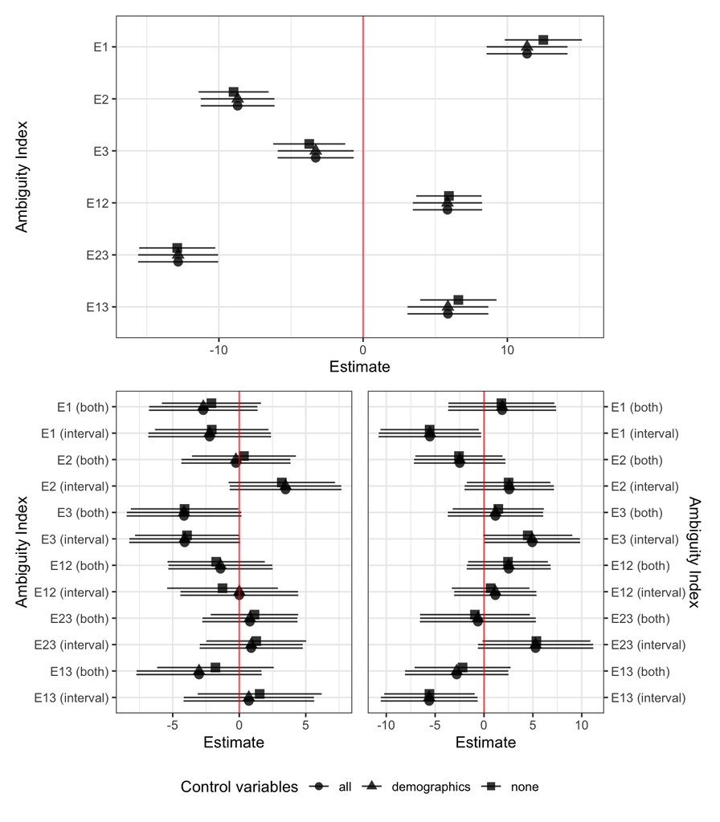

Figure 8: Treatment effects of regression equation (1) with matching probabilities for all events as depen- dent variables. Estimators with 95% confidence intervals. The underlying standard errors (“HC1”) are clustered at the individual level and estimated with the R package sandwich (Zeileis, 2004; Zeileis et al., 2020).

```r
(top / (left | right) & theme(legend.position = "bottom")) + plot_layout(guides = "collect")
```